# Woonfraude Analyse

27 mei 2021

## Woonfraude

### probleemstelling

## Businesscase

Stel je voor dat we een datascience model kunnen ontwikkelen dat voorspelt wat de kans is dat er sprake is van woonfraude op een bepaald adres.

Woonfraude definiëren we daarbij als: **De hoofdhuurder heeft niet zijn hoofdverblijf in de woning**.

Met een datascience analyse beogen we op basis van verschillende kenmerken:

1. Het aantal onnodige onderzoeken te reduceren
2. Willen we adressen kunnen onderscheiden met een verhoogd risico op woonfraude om onderzoek door medewerkers effectiever te laten zijn.

De analyse leidt tot een kans op woonfraude per adres op basis waarvan de beslissing genomen kan worden om wel of niet de casus te gaan onderzoeken.

## Dataset

De dataset is afkomstig van Stichting Thuisvester en bevat geanonimiseerde data over 347 onderzoeksdossiers naar woonfraude uit de periode 2013-2020, met o.a. als variabelen woonduur, inkomen bij woningtoewijzing, aantal reparatieverzoeken sinds ingang huurcontract, tijd sinds laatste wijziging betaalwijze, netto huur, bouwjaar, leeftijd hoofdhuurder, huishoudgrootte en eventuele aanvragen woningruil/huisbewaring.

```r
# Tip : leer jezelf aan het laden van de bibliotheken daar te doen waar je ze nodig hebt
library(janitor)

# De kolomnamen schonen van spaties en leestekens t.b.v. leesbaarheid
df <- clean_names(df.org)
```

## Filter relevante kolommen

```r
require(dplyr)

# Welke kolommen/variabelen zijn voor de vraagstelling relevant?
# Daartoe filteren we het dataframe.

df.filtered <- df %>% select(woonfraude_aangetoond,
              ingangsdatum_huurcontract,
              huishoudgrootte,
              inkomenstoets_bij_ingang,
              geboortedatum_hoofdhuurder,
              aantal_wijzigingen_betaalwijze_sinds_ingang_hc,
              aantal_reparatieverzoeken_eenheid_sinds_ingang_hc,
              aantal_interactielogposten_huisbewaring_woonruilverzoeken,
              oppervlakte,
              bouwjaar,
              netto_huur,
              maand_laatste_wijziging_betaalwijze)
```

```r
# Korte samenvatting van het gefilterde dataframe
summary(df.filtered)
```

```
##  woonfraude_aangetoond ingangsdatum_huurcontract     huishoudgrootte
##  Length:347            Min.   :1955-01-01 00:00:00   Min.   :1.000
##  Class :character      1st Qu.:2005-10-03 00:00:00   1st Qu.:1.000
##  Mode  :character      Median :2012-03-29 00:00:00   Median :1.000
##                        Mean   :2008-11-29 18:15:33   Mean   :1.135
##                        3rd Qu.:2015-02-15 00:00:00   3rd Qu.:1.000
##                        Max.   :2020-01-09 00:00:00   Max.   :5.000
##
##  inkomenstoets_bij_ingang geboortedatum_hoofdhuurder
##  Min.   :-6704            Min.   :1925-09-14 00:00:00
##  1st Qu.: 6893            1st Qu.:1961-09-29 12:00:00
##  Median :14173            Median :1973-05-27 00:00:00
##  Mean   :16398            Mean   :1972-10-03 09:24:22
##  3rd Qu.:23884            3rd Qu.:1985-01-09 00:00:00
##  Max.   :76798            Max.   :1999-01-03 00:00:00
##  NA's   :207
##  aantal_wijzigingen_betaalwijze_sinds_ingang_hc
##  Min.   :0.0000
##  1st Qu.:0.0000
##  Median :0.0000
##  Mean   :0.6571
##  3rd Qu.:1.0000
##  Max.   :9.0000
##
##  aantal_reparatieverzoeken_eenheid_sinds_ingang_hc
##  Min.   : 0.000
##  1st Qu.: 3.000
##  Median : 6.000
##  Mean   : 9.098
##  3rd Qu.:12.000
##  Max.   :42.000
##
##  aantal_interactielogposten_huisbewaring_woonruilverzoeken  oppervlakte
##  Min.   :0.000000                                          Min.   : 12.00
##  1st Qu.:0.000000                                          1st Qu.: 57.02
##  Median :0.000000                                          Median : 63.47
##  Mean   :0.002882                                          Mean   : 64.04
##  3rd Qu.:0.000000                                          3rd Qu.: 72.61
##  Max.   :1.000000                                          Max.   :166.00
##
##     bouwjaar      netto_huur    maand_laatste_wijziging_betaalwijze
##  Min.   :1920   Min.   :159.2   Min.   :1955-01-01 00:00:00
##  1st Qu.:1966   1st Qu.:462.4   1st Qu.:2008-01-28 00:00:00
##  Median :1975   Median :612.3   Median :2013-11-21 00:00:00
##  Mean   :1975   Mean   :583.7   Mean   :2011-01-15 06:21:47
##  3rd Qu.:1983   3rd Qu.:680.6   3rd Qu.:2017-05-15 12:00:00
##  Max.   :2016   Max.   :953.4   Max.   :2021-03-09 00:00:00
##
```

## Missende waarden

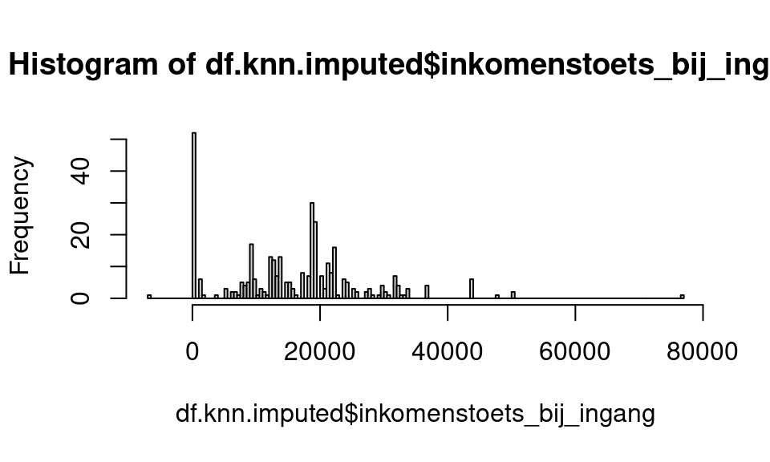

```r
# bevat kNN() impute
library(VIM)

# Er ontbreken soms waarden van de inkomenstoets bij ingang,
# door middel van de techniek Imputing de ontbrekende waarden genereren
# met behulp van K Nearest Neighbor
df.knn.imputed <- kNN(df.filtered, c("inkomenstoets_bij_ingang"))
hist(df.knn.imputed$inkomenstoets_bij_ingang, breaks=250)
```

## Verdere exploratie dataset

```r
# Wat voor variabelen typen zitten er in de data?
lapply(df,class)
```

```
## $woonfraude_aangetoond
## [1] "character"
##
## $ingangsdatum_huurcontract
## [1] "POSIXct" "POSIXt"
##
## $huishoudgrootte
## [1] "numeric"
##
## $inkomenstoets_bij_ingang
## [1] "numeric"
##
## $geboortedatum_hoofdhuurder
## [1] "POSIXct" "POSIXt"
##
## $aantal_wijzigingen_betaalwijze_sinds_ingang_hc
## [1] "numeric"
##
## $aantal_reparatieverzoeken_eenheid_sinds_ingang_hc
## [1] "numeric"
##
## $aantal_interactielogposten_huisbewaring_woonruilverzoeken
## [1] "numeric"
##
## $oppervlakte
## [1] "numeric"
##
## $bouwjaar
## [1] "numeric"
##
## $netto_huur
## [1] "numeric"
##
## $maand_laatste_wijziging_betaalwijze
## [1] "POSIXct" "POSIXt"
##
## $inkomenstoets_bij_ingang_imp
## [1] "logical"
```

## Verdere exploratie dataset 2

```r
# Tonen  van de eerste waarden op alle kolommen om een gevoel bij de data te krijgen
head(df, n=5)
```

```
##   woonfraude_aangetoond ingangsdatum_huurcontract huishoudgrootte
## 1                   Nee                2009-11-20               1
## 2                    Ja                2018-08-13               3
## 3                   Nee                2009-02-27               1
## 4                   Nee                2014-03-18               1
## 5                   Nee                2013-12-03               1
##   inkomenstoets_bij_ingang geboortedatum_hoofdhuurder
## 1                 25370.95                 1948-11-09
## 2                 43557.14                 1988-12-14
## 3                 18950.56                 1983-02-06
## 4                 13796.40                 1988-02-06
## 5                  7931.76                 1970-10-01
##   aantal_wijzigingen_betaalwijze_sinds_ingang_hc
## 1                                              0
## 2                                              0
```

[output cut: 27 more lines]

## Basale kansverdeling woonfraude op complete dataset

```r
# Kruistabel op de hoofdconclusie: was er sprake van woonfraude of niet?
t <- table(df$woonfraude_aangetoond)
prop.table(t)
```

```
##
##        Ja       Nee
## 0.2680115 0.7319885
```

## Data wrangling

```r
# Datums omzetten naar correcte datumformats
df$ingangsdatum_huurcontract <- as.Date(df$ingangsdatum_huurcontract)
df$geboortedatum_hoofdhuurder <- as.Date(df$geboortedatum_hoofdhuurder)

# Resetten als factor and relevellen
df$woonfraude_aangetoond <- as.factor(df$woonfraude_aangetoond)
df$woonfraude_aangetoond <- relevel(df$woonfraude_aangetoond,"Nee")

# Velden met kalenderdatums relatief maken, omdat tijdspanne in datascience wel iets zegt maar absolute momenten niet
df$rel_aant_dagen_laatste_wijz_betaalwijze <- as.numeric(Sys.Date()- as.Date(df$maand_laatste_wijziging_betaalwijze))
df$rel_geboortedatum_hoofdhuurder <- as.numeric(Sys.Date() - as.Date(df$geboortedatum_hoofdhuurder))
df$rel_aantal_dagen_contract<- as.numeric(Sys.Date() - as.Date(df$ingangsdatum_huurcontract))
```

### meer wrangling

```r
# Schalen van variabelen om ze onderling vergelijkbaar te maken
# Min gemiddelde , gedeeld door standaard deviatie leverd een zogenaamde z-score
df$inktoets.sc <- scale(df$inkomenstoets_bij_ingang)
df$nettohuur.sc <-scale(df$netto_huur)
df$bouwjaar.sc <- scale(df$bouwjaar)
df$huishoudgrootte.sc <- scale(df$huishoudgrootte)
df$aantal_reparatieverzoeken_eenheid_sinds_ingang_hc.sc <- scale(df$aantal_reparatieverzoeken_eenheid_sinds_ingang_hc)
df$aantal_interactielogposten_huisbewaring_woonruilverzoeken.sc <- scale(df$aantal_interactielogposten_huisbewaring_woonruilverzoeken)
df$oppervlakte.sc <-scale(df$oppervlakte)

# Welke kolommen/variabelen zijn voor de vraagstelling relevant? Daartoe filteren we het dataframe.
df <- df %>% select(woonfraude_aangetoond,
                    rel_aant_dagen_laatste_wijz_betaalwijze,
                    rel_geboortedatum_hoofdhuurder,
                    rel_aantal_dagen_contract,
                    inktoets.sc,
                    nettohuur.sc,
                    bouwjaar.sc,
                    huishoudgrootte.sc,
                    aantal_reparatieverzoeken_eenheid_sinds_ingang_hc.sc,
                    aantal_interactielogposten_huisbewaring_woonruilverzoeken.sc)
```

## Bouwen van het model!

Eerste de dataset opsplitsen in training en validatie deel

```r
# Kies een seed voor de randomizer als je herhaalbare trainings en validatie set wilt hebben
set.seed(1234)
# De data splitsen in een training en een validatie set
proportion.trn <- 0.7
index <- sample(1:nrow(df),round(proportion.trn*nrow(df)))
df.trn <- df[index,]
df.vld <- df[-index,]
```

## Random Forest

```r
library(randomForest)

# Zoeken naar de beste gecombineerde functie van variabelen door het maken van een Random #Forest
rf.formula <- as.formula(woonfraude_aangetoond ~ .)
m.rf.woonfraude <- randomForest(rf.formula, df.trn,)
```

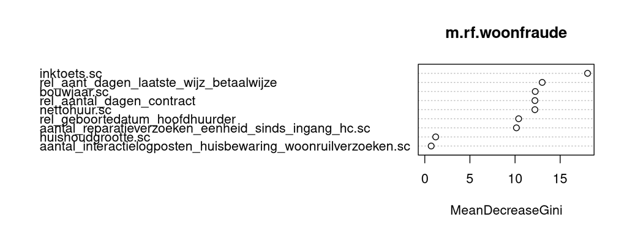

```r
# Het plotten van de resultaten: welke variabelen hebben veel invloed ?
varImpPlot(m.rf.woonfraude)
```

## Evaluatie Random Forest

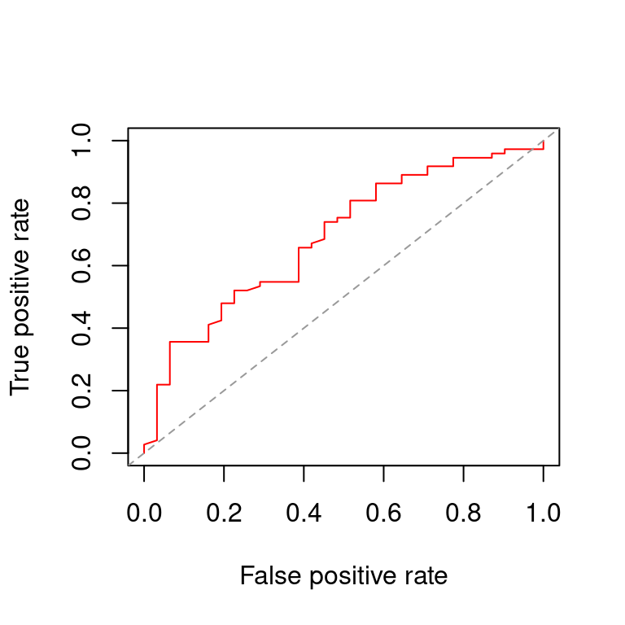

```r
# De Random Forest runnen op de validatie data en kijken hoeveel
# vals positieve inschattingen het model maakt.
m.rf.predicted <- predict(m.rf.woonfraude, newdata = df.vld, type = 'prob')
m.rf.pred <- ROCR::prediction(m.rf.predicted[,1],df.vld$woonfraude_aangetoond)
m.rf.perf <- ROCR::performance(m.rf.pred, "tpr", "fpr")
plot(m.rf.perf, col='Red')
abline(0,1,col="gray60",lty=2)
```

## Beslisbomen met Rpart

We gebruiken hier alleen de variabelen waarvan de random forest ze belangrijk vond.

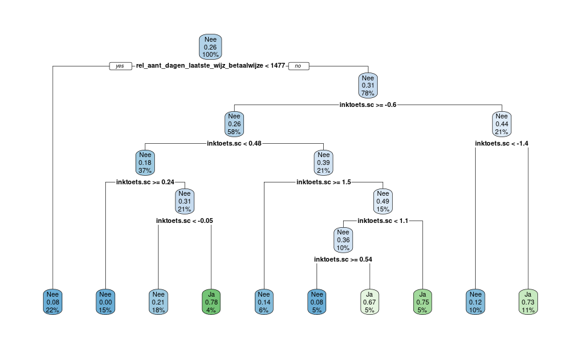

```r
require(rpart)
require(rpart.plot)
# 1.Beslisboom op basis van aantal dagen sinds wijziging betaalwijze en inkomenstoets bij ingang.
formule1 = as.formula("woonfraude_aangetoond ~ rel_aant_dagen_laatste_wijz_betaalwijze + inktoets.sc")
m.dt.woonfraude <- rpart(formule1, data = df.trn, method = "class")
rpart.plot(m.dt.woonfraude)
```

## Snoeien van de beslisboom 1 overfit of underfit

Kijken naar de complexiteit parameter, zodat we kunnen zien hoe groot de boom moet worden.

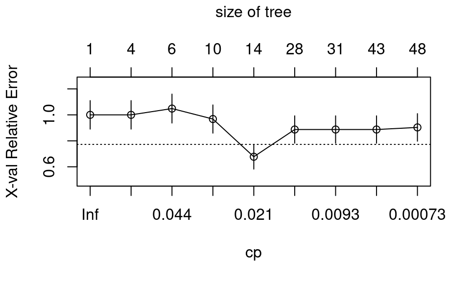

```r
m.dt.woonfraude.groot <- rpart(formule1,
                            data = df.trn,
                            method = "class",
                            control = rpart.control(minsplit = 2, xval = 250, cp = 0.0001)
                            )

plotcp(m.dt.woonfraude.groot)
```

## Vervolg

[figure not shown]

```r
m.dt.woonfraude.p <- prune(m.dt.woonfraude, cp=0.021)
par(mfrow=c(1,2))
rpart.plot(m.dt.woonfraude.groot,main="Full tree model")
```

## Gesnoeide boom model 1

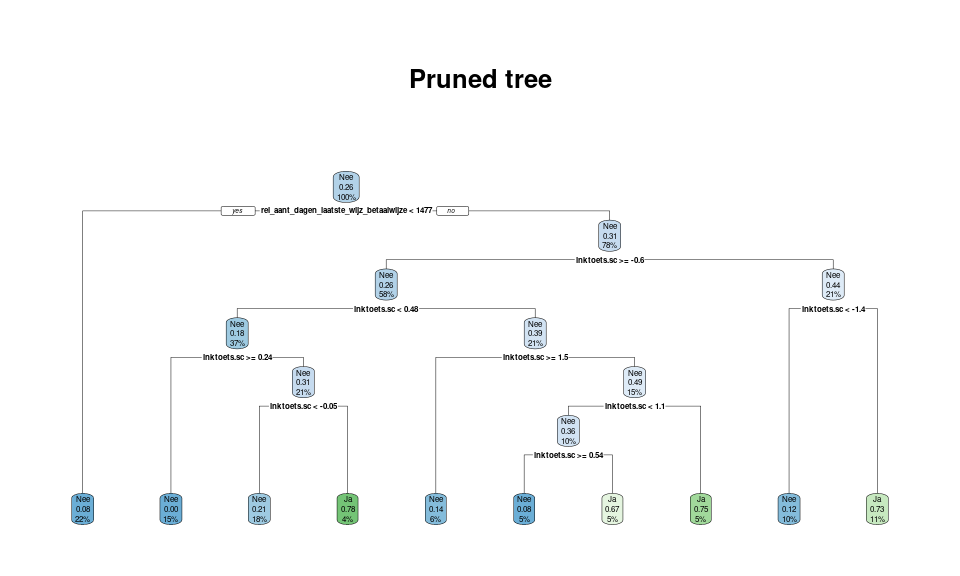

```r
rpart.plot(m.dt.woonfraude.p, main="Pruned tree")
```

## Beslisboom op basis van alle variabelen.

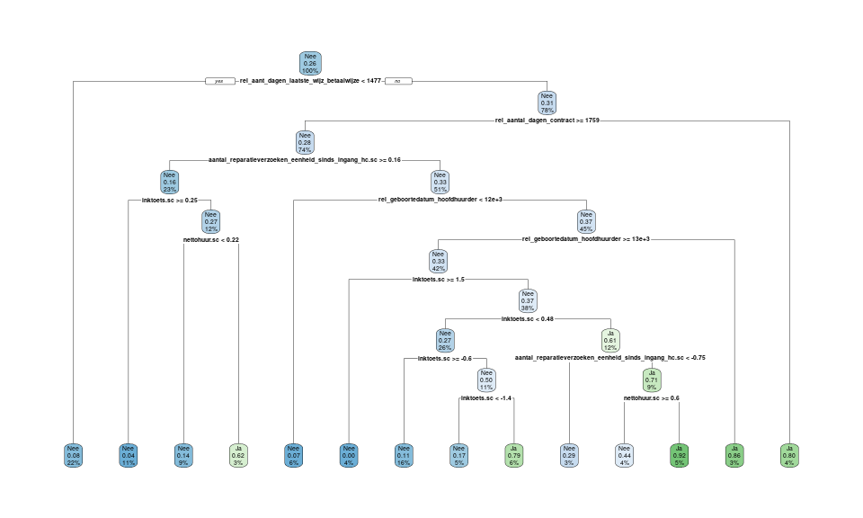

```r
m.dt.woonfraude.2 <- rpart(woonfraude_aangetoond ~ .,data = df.trn, method = "class")
rpart.plot(m.dt.woonfraude.2)
```

## Snoeien van de beslisboom 2 overfit of underfit

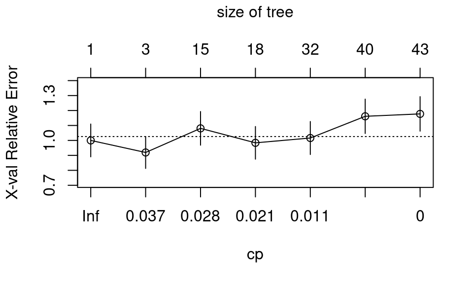

```r
m.dt.woonfraude.2.groot <- rpart(woonfraude_aangetoond ~ .,
                            data = df.trn,
                            method = "class",
                            control = rpart.control(minsplit = 2, xval = 200, cp = 0)
                            )
plotcp(m.dt.woonfraude.2.groot)
```

## Vervolg

Hier heb je nu een interesante keuz, bij een cp van 0.037 heb je maar drie blaadjes. Bij cp=0.021 heb je er 18.

[figure not shown]

```r
m.dt.woonfraude.2.p <- prune(m.dt.woonfraude.2, cp=0.021)
par(mfrow=c(1,2))
rpart.plot(m.dt.woonfraude.2.groot,main="Full tree model")
```

## Gesnoeide boom model 2

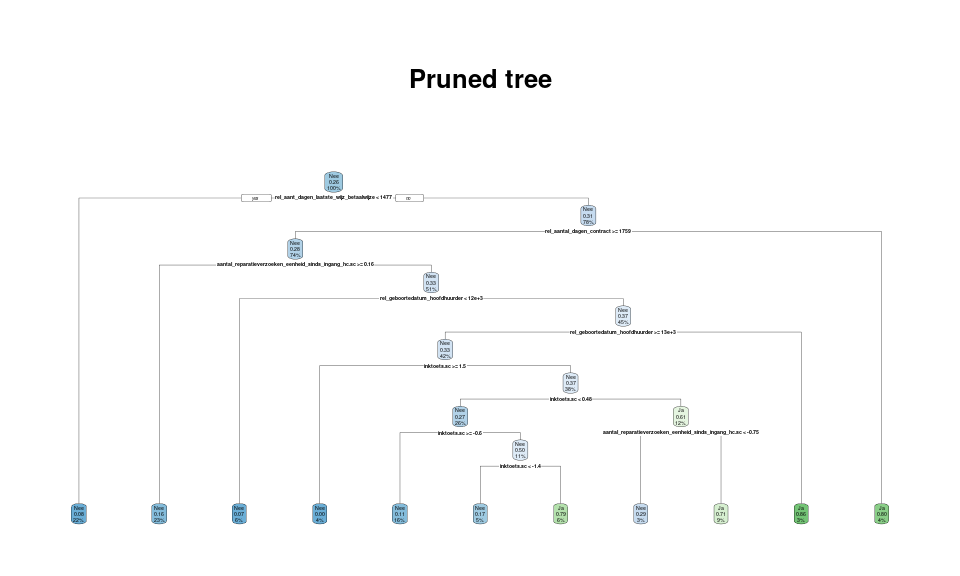

```r
rpart.plot(m.dt.woonfraude.2.p, main="Pruned tree")
```

## Beslisboom op basis van TOP 3

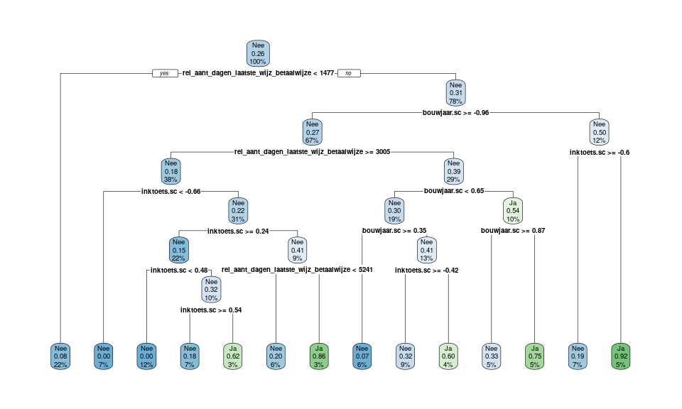

```r
formule3 = woonfraude_aangetoond ~ bouwjaar.sc +
  inktoets.sc + rel_aant_dagen_laatste_wijz_betaalwijze
m.dt.woonfraude.3 <- rpart(formule3,data = df.trn, method = "class")
rpart.plot(m.dt.woonfraude.3)
```

## Beslisboom op basis van TOP 5

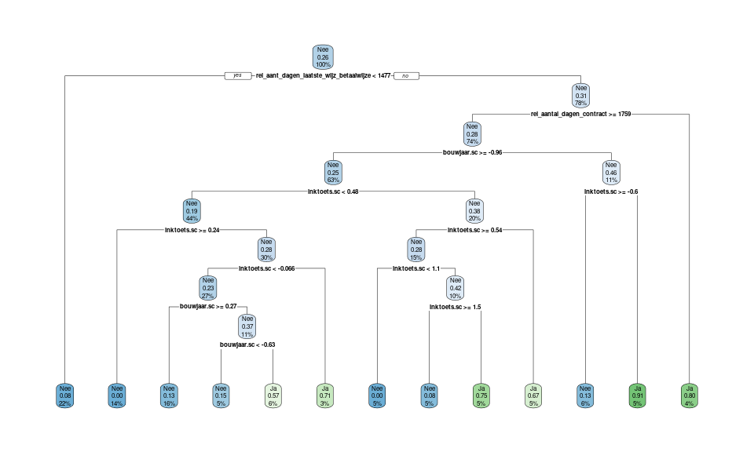

```r
formule4 = woonfraude_aangetoond ~ rel_aantal_dagen_contract + bouwjaar.sc +
  inktoets.sc + rel_aant_dagen_laatste_wijz_betaalwijze + nettohuur.sc
m.dt.woonfraude.4 <- rpart(formule4,data = df.trn, method = "class")
rpart.plot(m.dt.woonfraude.4)
```

## Performance van het model 1

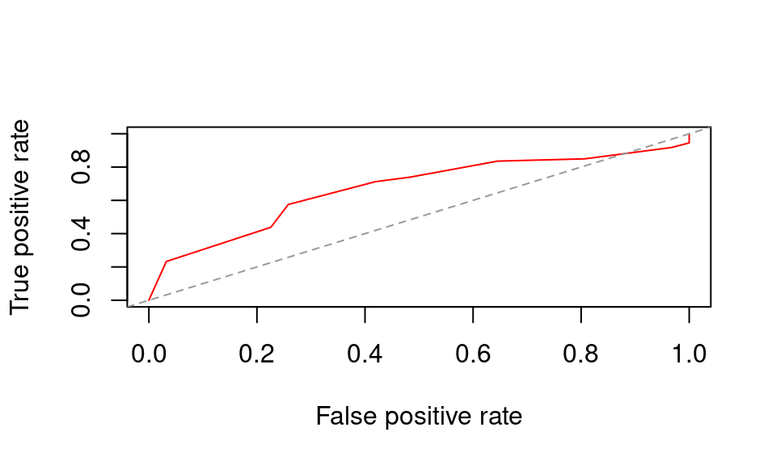

```r
require(ROCR)
m.dt.predicted <- predict(m.dt.woonfraude, newdata = df.vld, type = 'prob')
m.dt.pred <- prediction(m.dt.predicted[,1],df.vld$woonfraude_aangetoond)
m.dt.perf <- performance(m.dt.pred, "tpr", "fpr")
plot(m.dt.perf, col='Red')
abline(0,1,col="gray60",lty=2)
```

## ROC van alle modellen in één grafiek

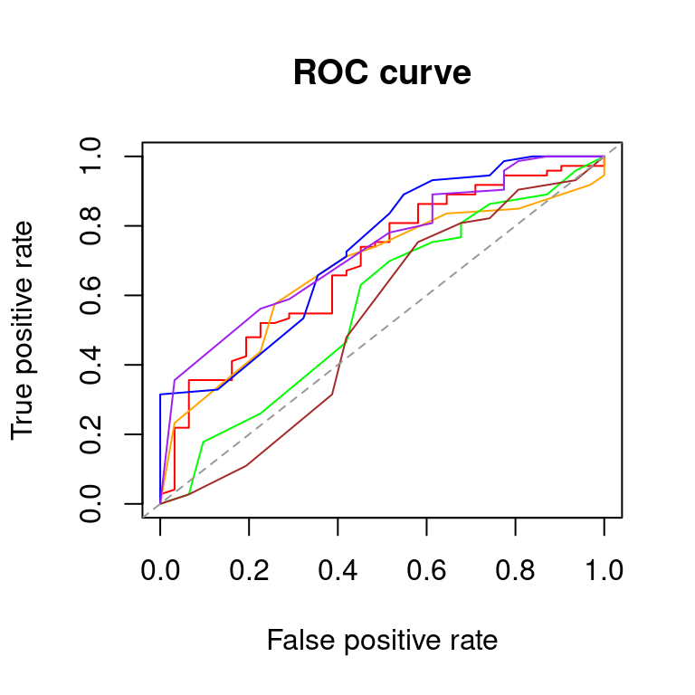

```r
plot(m.rf.perf, col='Red', main= "ROC curve")
plot(m.dt.perf, add=TRUE, col='Orange', main= "ROC curve")
plot(m.dt.perf.2, add=TRUE, col='Green')
plot(m.dt.perf.2p, add=TRUE, col='Brown')
plot(m.dt.perf.3, add=TRUE, col='Blue')
plot(m.dt.perf.4, add=TRUE, col='Purple')
abline(0,1,untf = FALSE, col="gray60",lty=2)
```

## Confusion matrix

```r
table(expected_value, m.rf.predicted.cls)
```

```
##               m.rf.predicted.cls
## expected_value Nee Ja
##            Nee  67  6
##            Ja   24  7
```

```r
table(expected_value, m.dt.predicted.2.cls)
```

```
##               m.dt.predicted.2.cls
## expected_value Nee Ja
##            Nee  59 14
##            Ja   21 10
```

```r
table(expected_value, m.dt.predicted.2p.cls)
```

```
##               m.dt.predicted.2p.cls
## expected_value Nee Ja
##            Nee  60 13
##            Ja   23  8
```

## Confusion tabellen model 3 en 4

```r
table(expected_value, m.dt.predicted.3.cls)
```

```
##               m.dt.predicted.3.cls
## expected_value Nee Ja
##            Nee  65  8
##            Ja   17 14
```

```r
table(expected_value, m.dt.predicted.4.cls)
```

```
##               m.dt.predicted.4.cls
## expected_value Nee Ja
##            Nee  59 14
##            Ja   19 12
```

## Conclusie business case

De totale business case wordt berekend op basis van de validatie dataset van 104 (of 30%) van het aantal cases uit de totale dataset:

- *True positive* : We voorspellen woonfraude, de kosten van onderzoek voor vaststelling bedragen gemiddeld € 350,-. Voor proces dat leidt tot einde huurovereenkomst komen hier nog werkdagen en proceskosten bij gemiddeld € 1400,-.
- *False positive* : We voorspellen woonfraude, gaan onderzoeken maar dat had niet gehoeven: We maken dus onderzoekskosten (a € 350,-) die we niet hadden hoeven maken.
- *False negative* : We voorspellen geen woonfraude, maar die is er in werkelijkheid wel. De situatie blijft gehandhaaft.
- *True negative* : We voorspellen geen woonfraude en die is ook niet aan de orde. We besparen hier onderzoekskosten ten opzichte van het niet gebruiken van een model.

## Model succes?

Model 3 presteert het best wanneer we een model willen selecteren op basis van de verhouding tussen false negatives en true negatives.

```r
# Wat is de succesrate op de gehele dataset??
t <- table(df$woonfraude_aangetoond)
prop.table(t)
```

```
##
##       Nee        Ja
## 0.7319885 0.2680115
```

[output not shown]

## Aanbevelingen en mogelijke verbeteringen

De data analyse kan nog verder doorontwikkeld worden door:

- Combinatie met externe data, waaronder uit systeem van woonruimteverdeling info over woningzoekenden (Kaster).
- Onderzoeken van meer criteria en op basis van ervaring bij andere corporaties registeren van meer data (bv. wie is melder) buren, medewerker of instantie en heeft dit invloed op de kans op woonfraude.
- Het model verder trainen op andere datasets.

## Vragen?

## Business Case

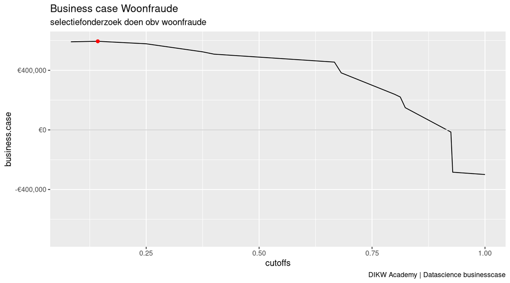

Optimal confusion matrix

```r
optimal.cutoff <- cutoffs[which.max(business.case)]
dfcm <- df.bc %>%
  filter(cutoffs == optimal.cutoff) %>%
  select(c(-cutoffs,-business.case))

matrix(dfcm,nrow=2)
```

```
##      [,1] [,2]
## [1,] 73   0
## [2,] 26   5
```